# # Reproducible Research Course : Peer Assessment 1

## Introduction

It is now possible to collect a large amount of data about personal movement using activity monitoring devices such as a Fitbit, Nike Fuelband, or Jawbone Up. These type of devices are part of the “quantified self” movement - a group of enthusiasts who take measurements about themselves regularly to improve their health, to find patterns in their behavior, or because they are tech geeks. But these data remain under-utilized both because the raw data are hard to obtain and there is a lack of statistical methods and software for processing and interpreting the data.

This assignment makes use of data from a personal activity monitoring device. This device collects data at 5 minute intervals through out the day. The data consists of two months of data from an anonymous individual collected during the months of October and November, 2012 and include the number of steps taken in 5 minute intervals each day.

Data Source: https://d396qusza40orc.cloudfront.net/repdata%2Fdata%2Factivity.zip

## Loading and preprocessing the data

- Loading the data

```r
  library(ggplot2) # Used ggplot2 system for plotting
  file_name="activity.csv"
  ## A new class is required to handle the date format.
  setClass('myDate')
  setAs("character","myDate", function(from) as.Date(from, format="%Y-%m-%d"))
  activity_data<-read.csv(file_name,colClasses=c("numeric", "myDate", "numeric"),header=T)
```

- Preprocessing the activity data

```r
calc_interval_activity <- function (activity_ds) {
    activity_interval <- aggregate (activity_ds$steps,by=list(interval=activity_ds$interval),FUN=mean,na.rm=T )

    colnames(activity_interval)<-c("interval","steps")

    activity_interval
  }
```

## What is mean total number of steps taken per day?

- Histogram of the total number of steps taken each day

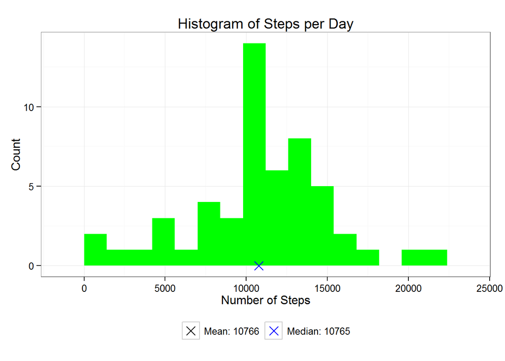

```r
plot_histogram <- function (activity_day,steps_mean,steps_median) {
  .e = environment()
  point_labels=c(paste(" Mean:",steps_mean),paste(" Median:",steps_median))
  point_color_1 = "black"
  point_color_2 = "blue"
  color_list=c(point_color_1,point_color_2)

  ggplot (activity_day, aes(x=steps), environment=.e) +
    geom_histogram(fill="green", binwidth=1400) +
    geom_point(aes(x=steps_mean,y=0,color=point_color_1),size=4,shape=4) +
    geom_point(aes(x=steps_median,y=0,color=point_color_2),size=4,shape=4) +
    scale_color_manual(name=element_blank(),labels=point_labels, values=color_list) +
    labs(title="Histogram of Steps per Day",x="Number of Steps",y="Count") +
    theme_bw() + theme(legend.position="bottom")
}

activity_day <- aggregate (steps ~ date, data=activity_data, FUN=sum)
steps_mean<-round(mean(activity_day$steps),0)
steps_median<-round(median(activity_day$steps),0)

plot_histogram(activity_day,steps_mean,steps_median)
```

- The mean and median total number of steps taken per day are :
- **Mean: 10766**
- **Median: 10765**

## What is the average daily activity pattern?

Time series plot (i.e. type = “l”) of the 5-minute interval (x-axis) and the average number of steps taken, averaged across all days (y-axis)

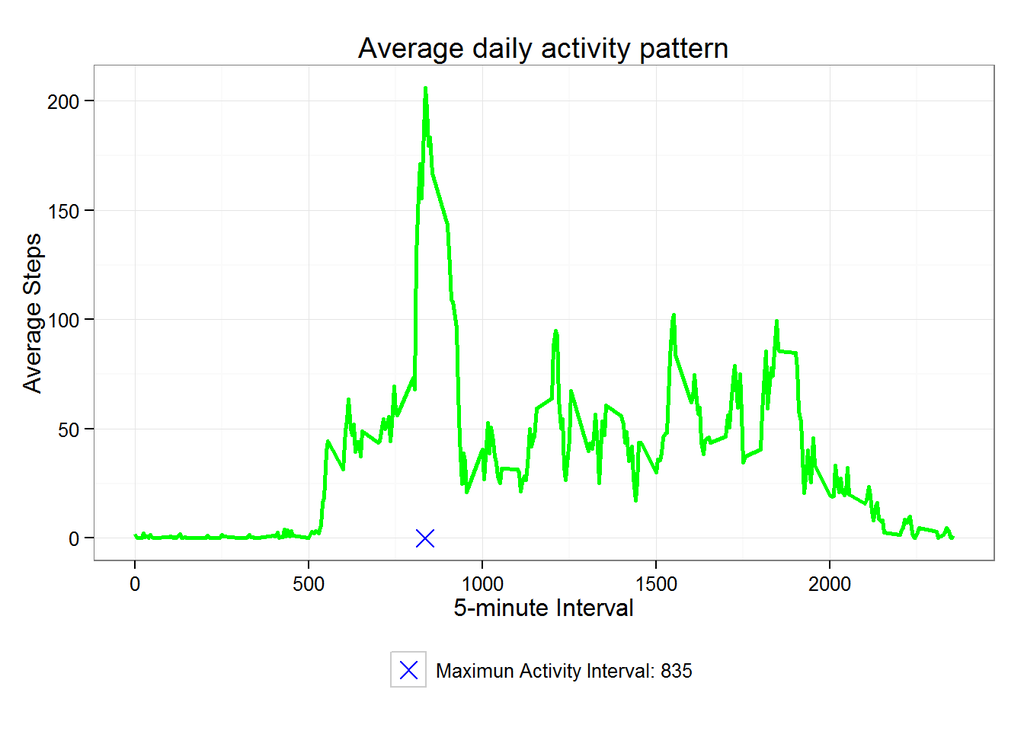

```r
  activity_interval <- calc_interval_activity (activity_data)
  steps_max<-which.max(activity_interval$steps)
  interval_max <- activity_interval[steps_max,]$interval
  point_labels <- c(paste(" Maximun Activity Interval:",interval_max))
  ggplot (activity_interval, aes(x=interval, y=steps)) +
     geom_line(color="green",size=1) +
     geom_point(aes(x=interval_max,y=0,color="blue"),size=4,shape=4) +
     scale_color_manual(name=element_blank(),labels=point_labels,values=c("blue")) +
     labs(title="Average daily activity pattern",x="5-minute Interval",y="Average Steps") +
     theme_bw() + theme(legend.position="bottom")
```

- The 5-minute interval, on average across all the days in the dataset, which contains the maximum number of steps is :
- **5-minute interval: 835**

## Imputing missing values

There are a number of days/intervals where there are missing values (coded as NA). The presence of missing days may introduce bias into some calculations or summaries of the data.

```r
sum(is.na(activity_data$steps)) # observations with missing data
```

```
## [1] 2304
```

## My strategy for imputing missing steps

```r
  indices_na <- which(is.na(activity_data$steps))

  replace_na <- unlist(lapply(indices_na, FUN=function(index) {
            interval = activity_data[index,]$interval
            activity_interval[activity_interval$interval==interval,]$steps
        }))

  activity_imputed <- data.frame (
    steps = activity_data$steps,
    date = activity_data$date,
    interval = activity_data$interval
  )
  activity_imputed$steps[indices_na]<-replace_na
```

- The summary of the new dataset with imputed values is :

```r
summary(activity_imputed)
```

```
##      steps            date               interval
##  Min.   :  0.0   Min.   :2012-10-01   Min.   :   0
##  1st Qu.:  0.0   1st Qu.:2012-10-16   1st Qu.: 589
##  Median :  0.0   Median :2012-10-31   Median :1178
##  Mean   : 37.4   Mean   :2012-10-31   Mean   :1178
##  3rd Qu.: 27.0   3rd Qu.:2012-11-15   3rd Qu.:1766
##  Max.   :806.0   Max.   :2012-11-30   Max.   :2355
```

- This is the histogram based on the imputed dataset

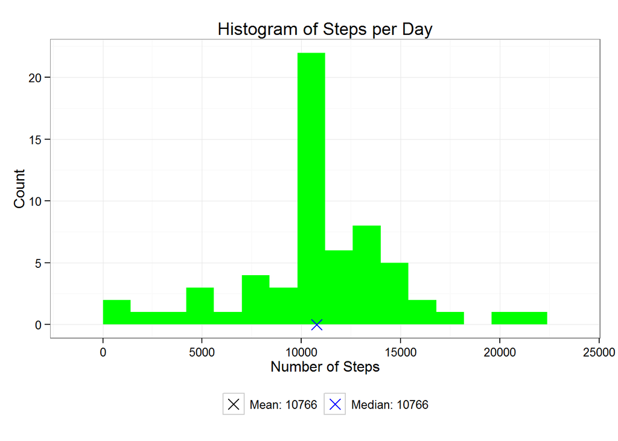

```r
activity_imputed_day <- aggregate (steps ~ date, data=activity_imputed, FUN=sum)
steps_imputed_mean<-round(mean(activity_imputed_day$steps),0)
steps_imputed_median<-round(median(activity_imputed_day$steps),0)

plot_histogram(activity_imputed_day,steps_imputed_mean,steps_imputed_median)
```

- While comparing with the original activity dataset, we observe that while the mean value remains the same, the median value has shifted closer to the mean and hence we have smaller variance and less skewness.
- The mean and median total number of steps taken per day are :
- **Mean: 10766**
- **Median: 10766**

## Are there differences in activity patterns between weekdays and weekends?

- The comparison plot is based on the filled-in missing values.

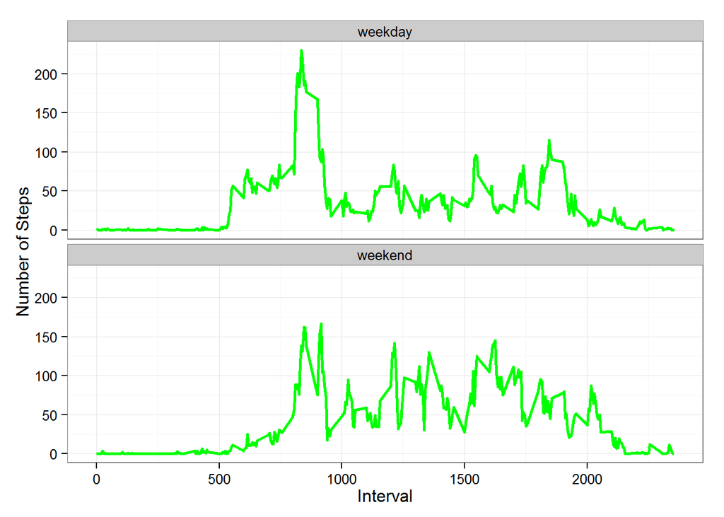

```r
  calc_week_activity <- function(activity_ds) {
      activity_ds$weekday<-as.factor(weekdays(activity_ds$date))

      wkend_data <- subset(activity_ds,weekday %in% c("Saturday","Sunday"))
      wkday_data <- subset(activity_ds,!weekday %in% c("Saturday","Sunday"))


      wkend_interval <- calc_interval_activity(wkend_data)
      wkday_interval <- calc_interval_activity(wkday_data)


      wkend_interval$daytype <- rep("weekend",nrow(wkend_interval))
      wkday_interval$daytype <- rep("weekday",nrow(wkday_interval))

      activity_week<- rbind(wkend_interval,wkday_interval)
      activity_week
  }

  activity_week<-calc_week_activity(activity_imputed)

  ggplot(activity_week, aes(x=interval,y=steps)) +
  geom_line(color="green",size=1) +
  facet_wrap(~daytype,nrow=2,ncol=1) +
  labs(x="Interval",y="Number of Steps") +
  theme_bw()
```